# Spatial Analysis with SPDEP: A demonstration of Hybrid Electric Vehicle Adoption

Craig Morton

16 November 2017

# Introduction

- This walkthrough is intended to demonstrate how to use the R programming environment to **conduct a research project**
- A series of packages will be used, with particular attention paid to **SPDEP**
- The walkthrough concentrates on a spatial analysis of the **adoption of Hybrid Electric Vehicles in the UK**
- You can get the project files from the following GitHub repository: https://github.com/clmorton/HEV
- Please feel free to **use this code in your our analyses** in the future
- This is a practical demonstration and will not cover underlining statistical theory

# SPDEP Package

- Available on CRAN and includes a number of functions for **spatial analysis and spatial econometrics**
- Facilitates the production of **spatial weights matrice**
- Has functions to calculate **spatial autocorrelation statistics**
- Allows for the estimation of **spatial regression models** using areal data

https://cran.r-project.org/web/packages/spdep/index.html

# Spatial Econometric Models

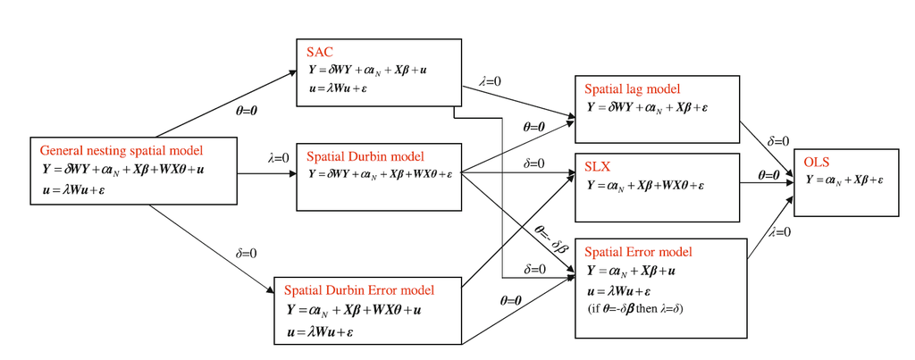

LeSage and Pace - Introduction to Spatial Econometrics https://www.crcpress.com/Introduction-to-Spatial-Econometrics/LeSage-Pace/p/book/9781420064247

Elhorst - Spatial Econometrics: From cross-sectional data to spatial panels http://www.springer.com/gb/book/9783642403392

# Hybrid Electric Vehicle Adoption

- Co-authored with Robin Lovelace and Jillian Anable
- Published in Transport Policy

[figure not shown]

http://www.sciencedirect.com/science/article/pii/S0967070X1730080X?via%3Dihub

# Hybrid Electric Vehicle Adoption

- Examines spatial variation in the **adoption of HEVs** across the local authorities of the UK
- Determines Whether the spatial variation displays any significant **geographic organisation**
- Considers if the rate of HEV uptake is associated with **nearness to the London Congestion Charge**